# Subsequent Infections - Prospective Cohort Analysis

This report provides a summary of available data on prospective cohorts. Attrition tables are attached to show available data vs. usable data, according to rough utilization criteria, along with a Table 1 for each cohort of study variables to the extent to which they are available at this stage of the study.

This report should be used to help select time anchors for sub-analyses, using the time series plots of cases below.

# Cohort availability

## Data timeframe

Data shown available from April 1, 2021 to October 1, 2023. Cohort entry periods and outcome periods may be fine tuned for final analysis.

### Attrition

Attrition table of patients that fit each cohort definition, and whether they are eligible for the study or not. We began with a cohort of patients roughly under 6 years of age (as a denominator), then fine-tuned age based on cohort entry date.

Eligibility requirements were:

1. Less than 5 years of age at the cohort entry date
2. Fits one of the cohort entrance criteria (flu, covid, or none)
3. Has a visit in the 1-6 months following cohort entry date
4. Has had a prior visit within 1.5 years of the cohort entry date

These criteria are broken down further in the following tables.

|  | Covid (N=92074) | Covid and influenza same day (N=726) | Covid prior to influenza (N=4449) | Influenza (N=29677) | Influenza prior to covid (N=1007) | No infection (N=717982) | Overall (N=845915) |
| --- | --- | --- | --- | --- | --- | --- | --- |
| study_eligible |  |  |  |  |  |  |  |
| 0.0 | 37310 (40.5%) | 332 (45.7%) | 864 (19.4%) | 14203 (47.9%) | 211 (21.0%) | 404157 (56.3%) | 457077 (54.0%) |
| 1.0 | 54764 (59.5%) | 394 (54.3%) | 3585 (80.6%) | 15474 (52.1%) | 796 (79.0%) | 313825 (43.7%) | 388838 (46.0%) |

|  | 0.0 (N=457077) | 1.0 (N=388838) | Overall (N=845915) |
| --- | --- | --- | --- |
| cohort_assignment |  |  |  |
| Covid | 37310 (8.2%) | 54764 (14.1%) | 92074 (10.9%) |
| Covid and influenza same day | 332 (0.1%) | 394 (0.1%) | 726 (0.1%) |
| Covid prior to influenza | 864 (0.2%) | 3585 (0.9%) | 4449 (0.5%) |
| Influenza | 14203 (3.1%) | 15474 (4.0%) | 29677 (3.5%) |
| Influenza prior to covid | 211 (0.0%) | 796 (0.2%) | 1007 (0.1%) |
| No infection | 404157 (88.4%) | 313825 (80.7%) | 717982 (84.9%) |

Table of eligibility requirement breakdown and attrition:

|  | Covid (N=92074) | Covid and influenza same day (N=726) | Covid prior to influenza (N=4449) | Influenza (N=29677) | Influenza prior to covid (N=1007) | No infection (N=717982) | Overall (N=845915) |
| --- | --- | --- | --- | --- | --- | --- | --- |
| study_eligible |  |  |  |  |  |  |  |
| 0.0 | 37310 (40.5%) | 332 (45.7%) | 864 (19.4%) | 14203 (47.9%) | 211 (21.0%) | 404157 (56.3%) | 457077 (54.0%) |
| 1.0 | 54764 (59.5%) | 394 (54.3%) | 3585 (80.6%) | 15474 (52.1%) | 796 (79.0%) | 313825 (43.7%) | 388838 (46.0%) |
| age_at_ce_under_limit |  |  |  |  |  |  |  |
| 0.0 | 7188 (7.8%) | 96 (13.2%) | 390 (8.8%) | 6577 (22.2%) | 116 (11.5%) | 107136 (14.9%) | 121503 (14.4%) |
| 1.0 | 84886 (92.2%) | 630 (86.8%) | 4059 (91.2%) | 23100 (77.8%) | 891 (88.5%) | 610846 (85.1%) | 724412 (85.6%) |
| satisfied_prior_visit_criteria |  |  |  |  |  |  |  |
| Yes | 80132 (87.0%) | 626 (86.2%) | 4227 (95.0%) | 27096 (91.3%) | 944 (93.7%) | 622661 (86.7%) | 735686 (87.0%) |
| No | 11942 (13.0%) | 100 (13.8%) | 222 (5.0%) | 2581 (8.7%) | 63 (6.3%) | 95321 (13.3%) | 110229 (13.0%) |
| has_visit_in_followup_period |  |  |  |  |  |  |  |
| Yes | 63615 (69.1%) | 490 (67.5%) | 4116 (92.5%) | 20447 (68.9%) | 951 (94.4%) | 392744 (54.7%) | 482363 (57.0%) |
| No | 28459 (30.9%) | 236 (32.5%) | 333 (7.5%) | 9230 (31.1%) | 56 (5.6%) | 325238 (45.3%) | 363552 (43.0%) |
| cohort_entry_date_in_window |  |  |  |  |  |  |  |
| Yes | 91997 (99.9%) | 726 (100%) | 4446 (99.9%) | 29677 (100%) | 1007 (100%) | 717982 (100%) | 845835 (100.0%) |
| No | 77 (0.1%) | 0 (0%) | 3 (0.1%) | 0 (0%) | 0 (0%) | 0 (0%) | 80 (0.0%) |

### Follow up time from cohort entry

The motivation for our outcomes of interest arose from clinically motivated signals in the data, namely, spikes in the return of common respiratory illnesses following the relaxation of pandemic-era restrictions. We have identified two specific outcome periods of interest, and have designed cohort entry periods that will align, more or less, with the outcome periods of interest.

The outcome periods of interest are:

• Any subsequent infection or any respiratory infection: December 2021 to March 2023 o Proposed cohort entry period: Index infection from June 2021 to February 2023

• RSV infections from September 2022 to February 2023 o Proposed cohort entry period: Index infection from March 2022 to January 2023

While it is impossible to capture a perfect cohort entry period that aligns with these outcome periods for certain, we have defined the cohort entry periods to begin up to six months prior to the start of the outcome period of interest, and to close one month prior to the end of the outcome period of interest. This way, we will capture all possible patient follow up that fall within the outcome periods of interest.

The following plots show the time series of COVID and Influenza index cases, in dark orange and blue shades, respectively. The *lighter shaded shadows* show the projected density of *follow up times* for each cohort, 30 to 180 days following the index period. The proposed outcome periods of interest are shown as horizontal lines at the bottom of the plot.

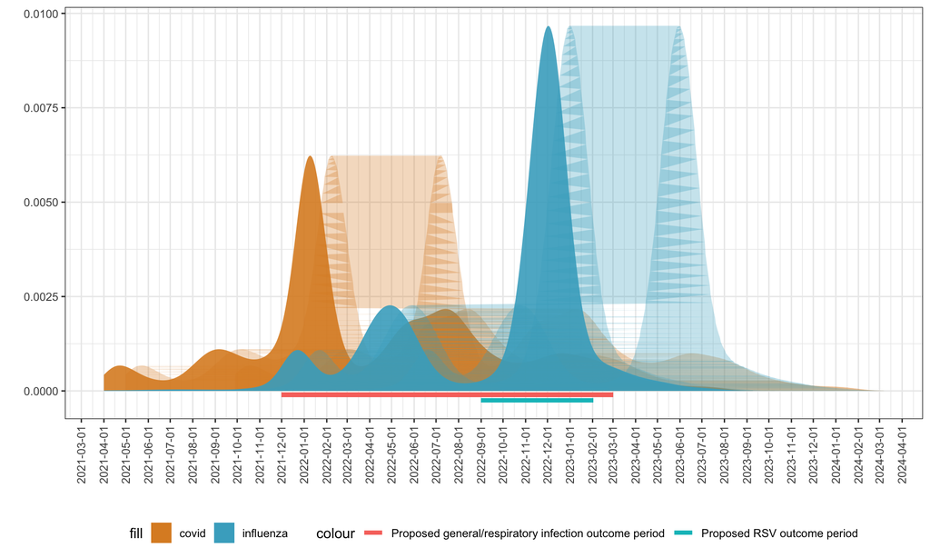

### Proposed primary outcome periods

Outcomes of interest have the following time anchors:

- Any subsequent infection: December 2021 to March 2023
  - Proposed cohort entry period: Index infection from June 2021 to February 2023
- Any respiratory infection: December 2021 to March 2023
  - Proposed cohort entry period: Index infection from June 2021 to February 2023
- RSV infections from September 2022 to February 2023
  - Proposed cohort entry period: Index infection from March 2022 to January 2023

The following plots visualize what the proposed cohort entry and subsequent outcome periods of interest will look like.

The following plots show the time series of COVID and Influenza index cases, in dark orange and blue shades, respectively. The *lighter shaded shadows* show the projected density of *follow up times* for each cohort, 30 to 180 days following the index period.

The proposed outcome periods of interest are shown as *pink* horizontal lines at the bottom of the plot.

The suggested cohort entry periods and subsequent follow up periods are shown as pairs of dark and light dashed lines.

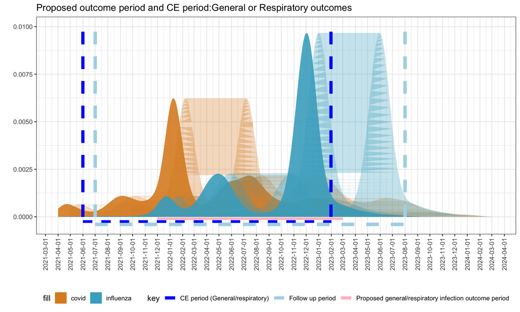

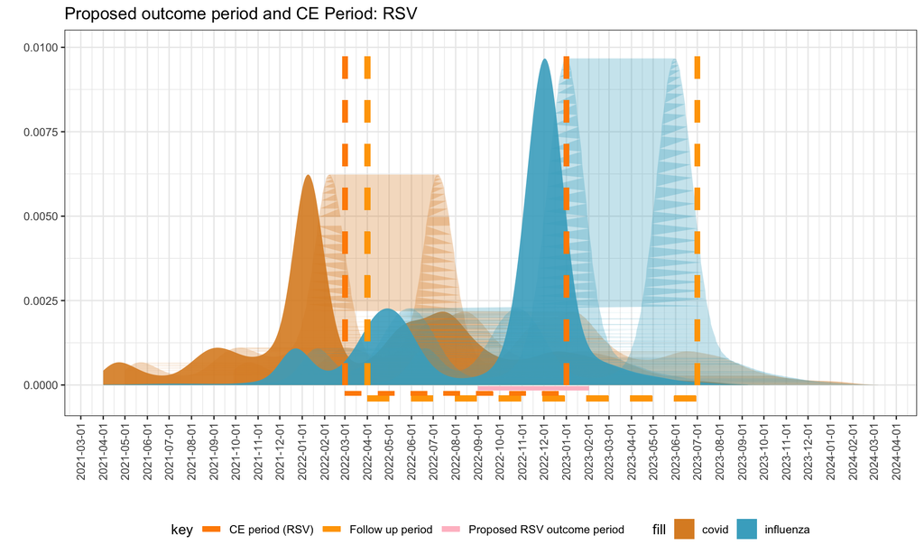

### Table 1 of study eligible patients

To help with understanding what we will obtain once we finalize the cohorts, the following is a Table 1 of demographic and study-related matching criteria variables. The cohort in the following table is limited to patients satisfying the study eligbility criteria (shown above), and only patients with covid, influenza, or no infection are shown (the other overlapping cohort patients have been removed). This table describes age, sex, race/ethnicity, and utilization data (coarse grained, will be fine-tuned). Cohort entry week distributions are shown in a figure below.

|  | Covid (N=54764) | Influenza (N=15474) | No infection (N=313825) | Overall (N=384063) |
| --- | --- | --- | --- | --- |
| sex_cat |  |  |  |  |
| Female | 24734 (45.2%) | 7115 (46.0%) | 141308 (45.0%) | 173157 (45.1%) |
| Male | 30028 (54.8%) | 8359 (54.0%) | 172508 (55.0%) | 210895 (54.9%) |
| Other/unknown | 2 (0.0%) | 0 (0%) | 9 (0.0%) | 11 (0.0%) |
| race_eth_cat |  |  |  |  |
| Hispanic | 9472 (17.3%) | 3374 (21.8%) | 51821 (16.5%) | 64667 (16.8%) |
| NH_Asian/PI | 3273 (6.0%) | 1024 (6.6%) | 17860 (5.7%) | 22157 (5.8%) |
| NH_Black/AA | 9526 (17.4%) | 4385 (28.3%) | 55838 (17.8%) | 69749 (18.2%) |
| NH_Multiple | 2769 (5.1%) | 746 (4.8%) | 15453 (4.9%) | 18968 (4.9%) |
| NH_White | 24726 (45.2%) | 4987 (32.2%) | 145183 (46.3%) | 174896 (45.5%) |
| Other/Unknown | 4998 (9.1%) | 958 (6.2%) | 27670 (8.8%) | 33626 (8.8%) |
| age_cat_at_ce |  |  |  |  |
| <6 months | 8995 (16.4%) | 1056 (6.8%) | 50440 (16.1%) | 60491 (15.8%) |
| 1-2y old | 12569 (23.0%) | 3059 (19.8%) | 64517 (20.6%) | 80145 (20.9%) |
| 2-3y old | 8745 (16.0%) | 2960 (19.1%) | 56957 (18.1%) | 68662 (17.9%) |
| 3-4y old | 7180 (13.1%) | 3190 (20.6%) | 53388 (17.0%) | 63758 (16.6%) |
| 4-5y old | 6377 (11.6%) | 3427 (22.1%) | 51608 (16.4%) | 61412 (16.0%) |
| 6m-1y old | 10898 (19.9%) | 1782 (11.5%) | 36915 (11.8%) | 49595 (12.9%) |
| visit_type_inpatient_or_ed |  |  |  |  |
| No visits | 29350 (53.6%) | 6718 (43.4%) | 177328 (56.5%) | 213396 (55.6%) |
| Num visits >= 1 | 24130 (44.1%) | 8265 (53.4%) | 124085 (39.5%) | 156480 (40.7%) |
| Num visits >= 141 | 0 (0%) | 0 (0%) | 1 (0.0%) | 1 (0.0%) |
| Missing | 1284 (2.3%) | 491 (3.2%) | 12411 (4.0%) | 14186 (3.7%) |
| visit_type_outpatient |  |  |  |  |
| No visits | 5164 (9.4%) | 1581 (10.2%) | 38419 (12.2%) | 45164 (11.8%) |
| Num visits >= 1 | 6514 (11.9%) | 2026 (13.1%) | 51979 (16.6%) | 60519 (15.8%) |
| Num visits >= 2 | 9944 (18.2%) | 2922 (18.9%) | 71627 (22.8%) | 84493 (22.0%) |
| Num visits >= 4 | 31858 (58.2%) | 8454 (54.6%) | 139388 (44.4%) | 179700 (46.8%) |
| Num visits >= 364 | 0 (0%) | 0 (0%) | 1 (0.0%) | 1 (0.0%) |
| Missing | 1284 (2.3%) | 491 (3.2%) | 12411 (4.0%) | 14186 (3.7%) |
| visit_type_admin_other_telemed |  |  |  |  |
| No visits | 3489 (6.4%) | 822 (5.3%) | 20830 (6.6%) | 25141 (6.5%) |
| Num visits < 2 | 4518 (8.3%) | 1206 (7.8%) | 35473 (11.3%) | 41197 (10.7%) |
| Num visits >= 2 | 6484 (11.8%) | 1910 (12.3%) | 52393 (16.7%) | 60787 (15.8%) |
| Num visits >= 4 | 8369 (15.3%) | 2747 (17.8%) | 58494 (18.6%) | 69610 (18.1%) |
| Num visits >= 7 | 30620 (55.9%) | 8297 (53.6%) | 134224 (42.8%) | 173141 (45.1%) |
| Num visits >= 309 | 0 (0%) | 1 (0.0%) | 0 (0%) | 1 (0.0%) |
| Missing | 1284 (2.3%) | 491 (3.2%) | 12411 (4.0%) | 14186 (3.7%) |

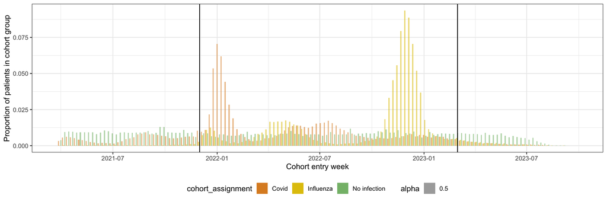

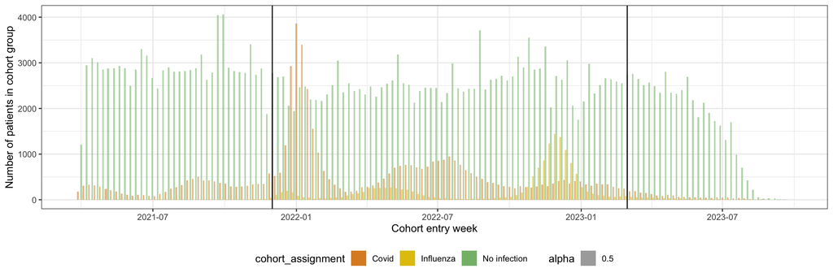

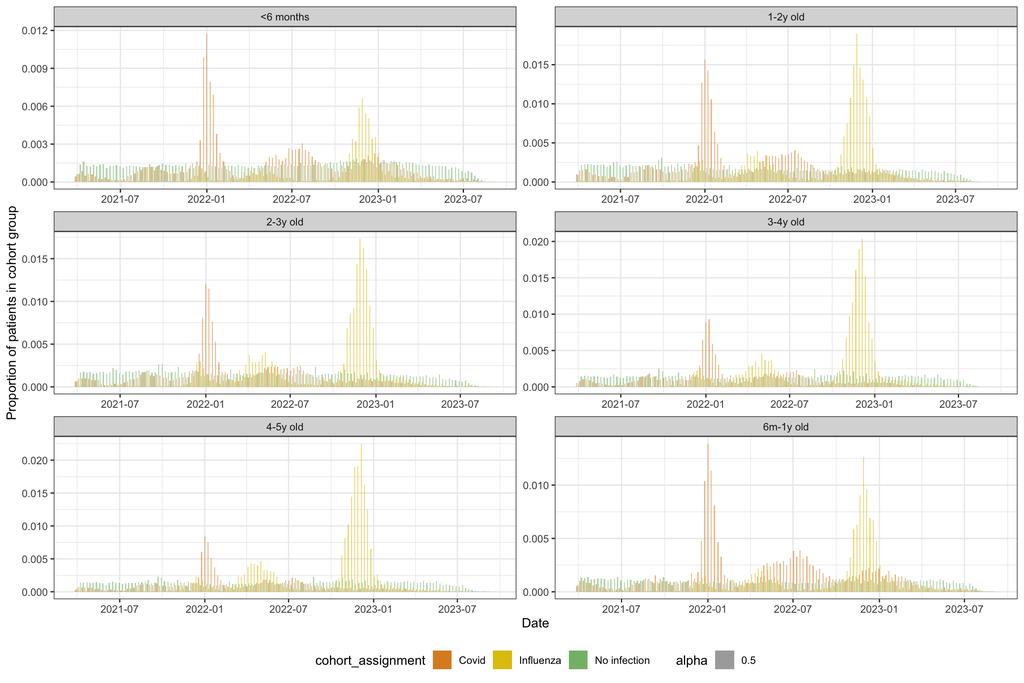

Comparative bar chart of matching variables broken down by cohort, to aid estimating if exact matching or propensity score matching is feasible. Counts are reporting on a log scale.

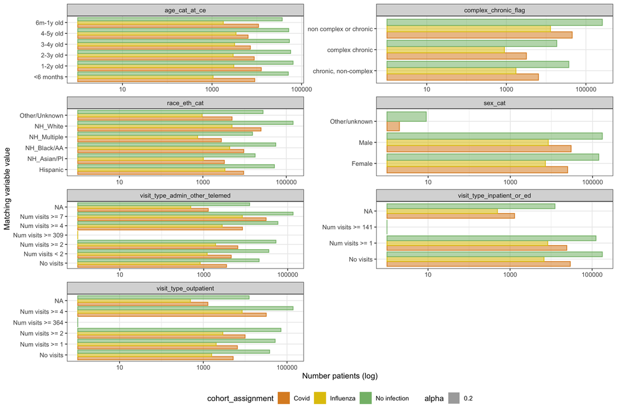